# Peer Assessment 1

# Loading the data and preprocessing

```r
activity <- read.csv("activity.csv")
head(activity)
```

```
##   steps       date interval
## 1    NA 2012-10-01        0
## 2    NA 2012-10-01        5
## 3    NA 2012-10-01       10
## 4    NA 2012-10-01       15
## 5    NA 2012-10-01       20
## 6    NA 2012-10-01       25
```

```r
names(activity)
```

```
## [1] "steps"    "date"     "interval"
```

```r
library(lattice)
activity$date<-as.Date(activity$date,'%Y-%m-%d')
```

# What is mean total number of steps taken per day?

1. Calculate the toral number of steps taken per day.
2. Make a histogram of the total number of steps taken each day

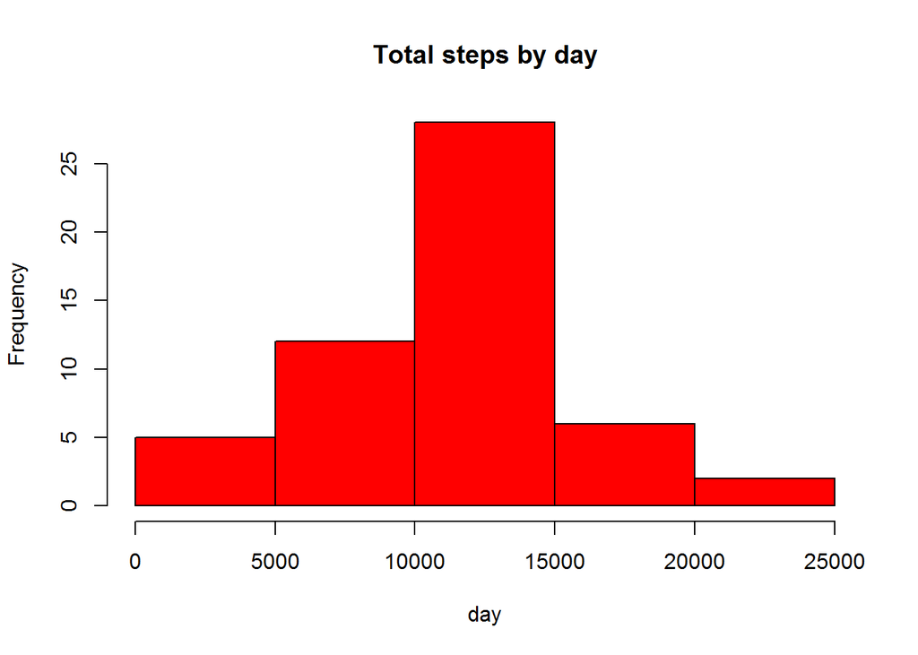

```r
totalsteps <- aggregate(steps~date,activity,sum,na.rm = TRUE)
hist(totalsteps$steps, main ="Total steps by day", xlab = "day", col = "red")
```

3. Calculate and report the mean and median of the total number of steps taken per day

```r
rmean<-mean(totalsteps$steps)
rmedian<-median(totalsteps$steps)
```

The mean is 1.076618910^{4} and the median is 10765

# What is the average daily activity parttern?

- Make a time series plot (i.e. type = “l”) of the 5-minute interval (x-axis) and the average number of steps taken, averaged across all days (y-axis)

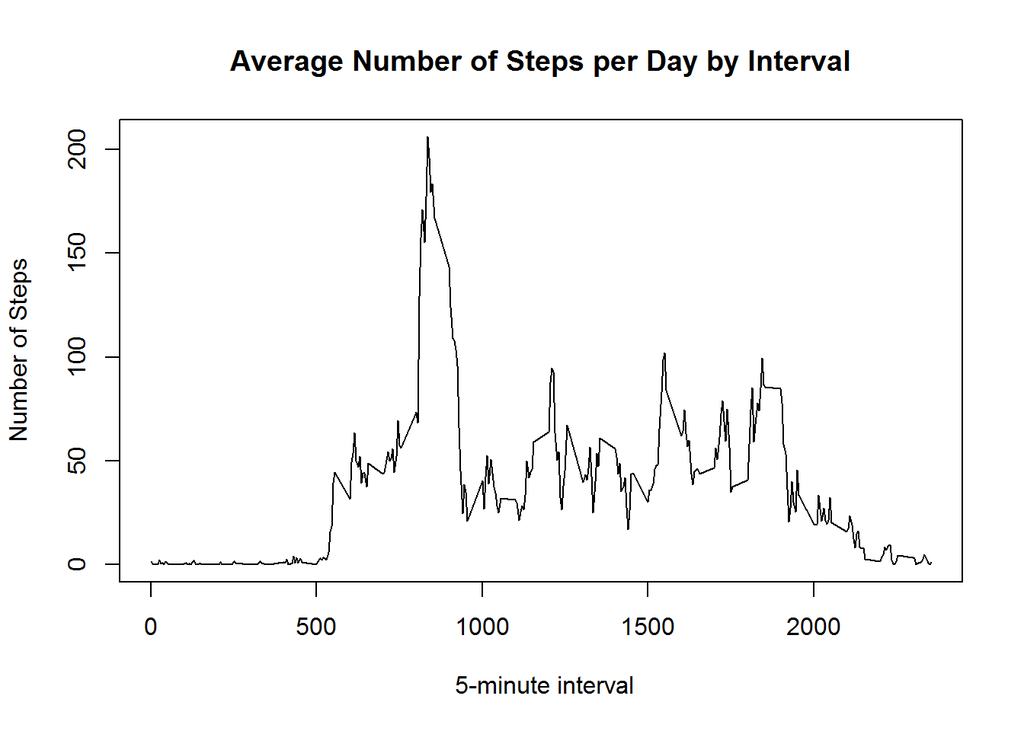

```r
steps_by_interval<-aggregate(steps~interval, activity,mean,na.rm = "TRUE")
plot(steps_by_interval$interval,steps_by_interval$steps, type = "l", xlab = " 5-minute interval",ylab="Number of Steps", main = "Average Number of Steps per Day by Interval")
```

Which 5-minute interval, on average across all the days in the dataset, contains the maximum number of steps?

```r
max_interval<-steps_by_interval[which.max(steps_by_interval$steps),1]
```

The 5-minute interval, on average across all the days in the data set, containing the maximum number of steps is 835

# Imputing missing values

```r
activity_NA <- sum(is.na(activity))
```

Devise a strategy for filling in all of the missing values in the dataset. The strategy does not need to be sophisticated. For example, you could use the mean/median for that day, or the mean for that 5-minute interval, etc.

Strategy: Use mean in 5 min interval to replace NA

```r
StepsAverage <- aggregate(steps ~ interval, activity, FUN = mean, na.rmm = TRUE)
fillNA <- numeric()
for (i in 1:nrow(activity)) {
    obs <- activity[i, ]
    if (is.na(obs$steps)) {
        steps <- subset(StepsAverage, interval == obs$interval)$steps
        } else {
            steps <- obs$steps
            }
    fillNA <- c(fillNA, steps)
    }
```

Create a new dataset that is equal to the original dataset but with the missing data filled in.

```r
new_activity <- activity
new_activity$steps <- fillNA
```

Make a histogram of the total number of steps taken each day and Calculate and report the mean and median total number of steps taken per day. Do these values differ from the estimates from the first part of the assignment? What is the impact of imputing missing data on the estimates of the total daily number of steps?

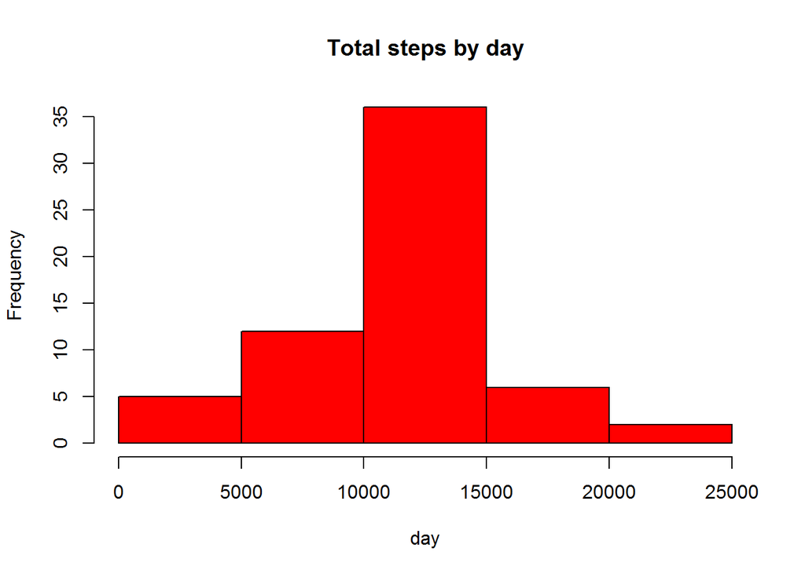

```r
StepsTotal2 <- aggregate(steps ~ date, data = new_activity, sum, na.rm = TRUE)
hist(StepsTotal2$steps, main = "Total steps by day", xlab = "day", col = "red")
```

```r
rmean2<-mean(StepsTotal2$steps)
rmedian2<-median(StepsTotal2$steps)
```

The mean is 1.076618910^{4} and median is 1.076618910^{4}.  
The mean is unchanged. But the median is different, because we add more point to the data thus shift the poisition of the median number.

# Are there differences in activity patterns between weekdays and weekends?

```r
Sys.setlocale("LC_TIME", "English")
```

```
## [1] "English_United States.1252"
```

```r
day <- weekdays(activity$date)
daylevel <- vector()
for (i in 1:nrow(activity)) {
    if (day[i] == "Saturday") {
        daylevel[i] <- "Weekend"
        }  else if (day[i] == "Sunday") {
            daylevel[i] <- "Weekend"
            }else {
                daylevel[i] <- "Weekday"
                }
    }
activity$daylevel <- daylevel
activity$daylevel <- factor(activity$daylevel)

stepsByDay <- aggregate(steps ~ interval + daylevel, data = activity, mean)
names(stepsByDay) <- c("interval", "daylevel", "steps")
```

Make a panel plot containing a time series plot (i.e. type = “l”) of the 5-minute interval (x-axis) and the average number of steps taken, averaged across all weekday days or weekend days (y-axis). The plot should look something like the following, which was creating using simulated data:

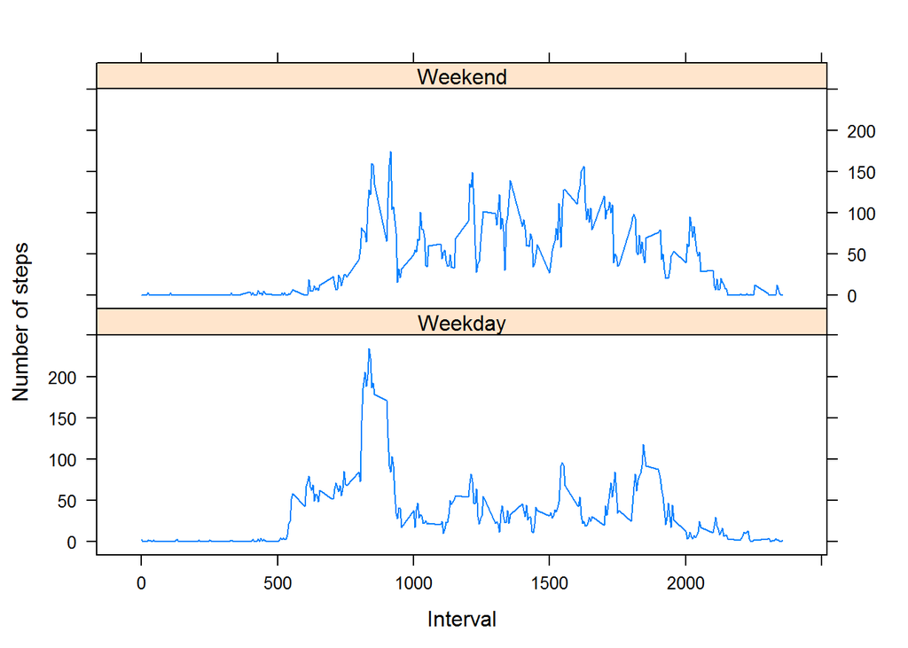

```r
library(lattice)
xyplot(steps ~ interval | daylevel, stepsByDay, type = "l", layout = c(1, 2),
       xlab = "Interval", ylab = "Number of steps")
```